# Release Notes for STM32 Key Management Services

Copyright © 2019 STMicroelectronics

[figure not shown]

# License

This software component is licensed by ST under Ultimate Liberty license SLA0044, the “License”;

You may not use this file except in compliance with the License.

You may obtain a copy of the License at: SLA0044

# Purpose

Key Management Services (KMS) provides cryptographic services through [the standard PKCS#11 APIs (developed by OASIS)](http://docs.oasis-open.org/pkcs11/pkcs11-base/v2.40/os/pkcs11-base-v2.40-os.html) allowing to abstract the key value to the caller (using object ID and not directly the key value). KMS can be executed inside a protected/isolated environment in order to ensure that key value can’t be accessed by an unauthorized code running outside the protected/isolated environment.

KMS manages 3 types of keys:

- Static Embedded keys :
  - Predefined keys embedded within the code that can’t be modified
- Updatable keys with Static ID :
  - Keys IDs are predefined in the system
  - Key(s) can be injected or updated in a NVM storage via a secure procedure usingStatic Embedded Keys(authenticity check, data integrity check and data decryption)
  - Key can’t be deleted
- Updatable keys with dynamic ID :
  - Keys IDs are defined when keys are created using KMS services
  - Key value can be updated using KMS services
  - Key can be deleted

KMS only supports a subset of PKCS#11 APIs:

- Object management functions: creation / update / deletion
- AES Encrypt & Decrypt functions
- SHA Digest functions
- RSA and ECDSA Sign / Verify functions

The figure below shows the overall KMS architecture.

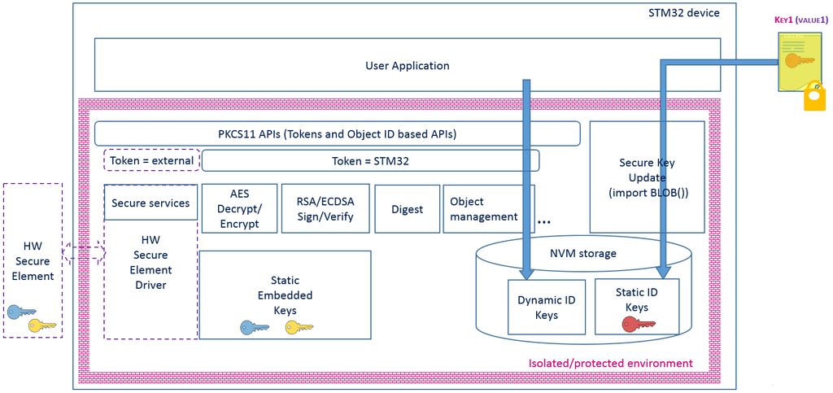

KMS overview

For more details, refer to [UM2262](https://www.st.com/st-web-ui/static/active/en/resource/technical/document/user_manual/DM00414687.pdf) : Getting started with X-CUBE-SBSFU expansion package, Chapter 4.

# Update History

v1.0.0-aws_2.0.0 / 12-March-2020

## Main Changes

**Changes required for PKCS#11 AFQP tests**

Implement the changes and fixes required to pass the PKCS#11 AFQP tests.

v1.0.0 / 13-July-2019

## Main Changes

### First official release

Official delivery of Key Management Services for STM32 series, compliant with PKCS#11 APIs from OASIS.

## Known Limitations

None